# Assignment 2 - DS4Biz Y63

## TextScraping_Classification

### Team Detail

**Team Name**: TomandJerry

### *Student 1*

**Student ID**: 61070306  
**Student Full Name**: นางสาว ปรียานุช สุภาสืบ

### *Student 2*

**Student ID**: 61070365  
**Student Full Name**: นางสาว อารีญา สมิงแก้ว

# news

```python
import requests
import bs4
from bs4 import BeautifulSoup
import pandas as pd
import numpy as np
import matplotlib.pyplot as plt
from sklearn.ensemble import RandomForestClassifier
from sklearn.svm import SVC
from sklearn.linear_model import LogisticRegression
from sklearn.neighbors import KNeighborsClassifier
from sklearn.model_selection import train_test_split
from sklearn.linear_model import LinearRegression
from sklearn.model_selection import cross_val_score
from sklearn.model_selection import RandomizedSearchCV, GridSearchCV
import xgboost as xgb
from xgboost import XGBClassifier
from sklearn.metrics import mean_squared_error
from sklearn.metrics import accuracy_score
from sklearn.metrics import classification_report
from sklearn import model_selection, naive_bayes, svm
import seaborn as sns
import nltk
import warnings
warnings.filterwarnings('ignore')
from sklearn.linear_model import SGDClassifier
from sklearn.pipeline import Pipeline
import numpy as np
from sklearn.metrics import confusion_matrix
from sklearn.model_selection import RandomizedSearchCV, GridSearchCV
from sklearn.model_selection import StratifiedKFold
```

# Part 1: Data Collection

- ## เเสดงกระบวนการ scrape บทความจากหน้าเว็บไซต์

### request หน้า web

```python
response = requests.get('http://www.it.kmitl.ac.th/~teerapong/news_archive/index.html') # ส่งคำขอไปยังหน้าเว็บที่เราต้องการ
print(response) # check ว่า ข้อความตอบกลับสามารถใช้ข้อมูลหน้าเว็บได้หรือไม่
# print(type(response))
# ถ้าคืนมาเท่ากับ404 คือ server ไม่มี
```

```
<Response [200]>
```

### Parsing the HTML with BeautifulSoup

```python
soup  = bs4.BeautifulSoup(response.content, 'lxml') # เลือกใช้ parser lxml
print(soup.prettify()) # มองเป็น html # เเสดงโค้ดหน้า html
```

[output not shown]

[output cut: 108 more lines]

[output not shown]

## scrape ข้อมูลจากหน้าเว็บไซต์

> มีการบวนการดังนี้
> 1. ดึงข้อมูล Article Category(target) เเละ Article Title หัวข้อข่าว
>    - ดึงชื่อ link ในเเต่ละเดือนเพื่อได้ link url ที่สมบูรณ์ ในเเต่ละเดือน
>    - เริ่มดึงข้อมูลทั้งหมดเเละเก็บใน DataFrame
>    - ทำความสะอาดข้อมูล ลบข้อมูลที่ไม่เกี่ยวข้อง เช่น ค่า null
>    - save ข้อมูล txt file --> ผลลัพธ์ที่ได้จะได้ target ของข่าวมาทั้งหมด
> 2. ดึงข้อมูลเนื้อหาข่าวรวมถึงหัวข้อข่าวด้วย
>    - get link in each title news เเละเก็บ link url ในรูปเเบบเต็ม
>    - ตั้งฟังก์ชั่นในการดึงข้อมูลหัวข้อข่าว เเละ เนื้อหาข่าว
>    - ดึงข้อมูลมาเก็บไว้ จะได้ รายการ list ข่าวในเเต่ละหัวข้อ ประกอบไปด้วยหัวข้อข่าวเเละเนื้อหาข่าวทั้งหหมด
>    - แปลงเป็น DataFrame เเละ save to txt file and csv file -> ผลลัพธ์ที่ได้ จะได้ไฟล์ทั้งสองรูปแบบคือมีเนื้อหาข่าวอย่างเดียว, ,มีเนื้อหาเเละหัวข้อข่าว

### ดึงชื่อ link ในเเต่ละเดือน

```python
# ลิ้งเเต่ละดือน
link_months = soup.find_all('a') # หา tag a
link_month = []
for link in link_months: # วนลูปทุกๆ tag a
    if 'href' in link.attrs: # ตั้งเงื่อนไขว่า ถ้า tag a มี href ให้นำค่าของ href ใส่ไว้ใน list link_month ที่ตั้งไว้
        link_month.append(link.attrs['href'])
#         print(str(link.attrs['href']))

# มีบางลิ้งค์ทีีไม่เกี่ยวข้องออกมาด้วย จำนวน 3 ค่าสุดท้าย จึงทำการลบ
for i in range(-3,0):
    link_month.pop(i)
link_month # เรียกดูรายการ link ในเเต่ละหัวข้อข่าว
```

```
['month-jan-2017.html',
 'month-feb-2017.html',
 'month-mar-2017.html',
 'month-apr-2017.html',
 'month-may-2017.html',
 'month-jun-2017.html',
 'month-jul-2017.html',
 'month-aug-2017.html',
 'month-sep-2017.html',
 'month-oct-2017.html',
 'month-nov-2017.html',
 'month-dec-2017.html']
```

### เก็บที่อยู่ link ทั้ง 12 เดือน หลังจากได้ชื่อท้ายของ link ที่เเตกต่าง

```python
link_months = [] # สร้าง list เพื่อเก็บ link ในเเต่ละเดือน
for link in link_month: # วนลูปเพื่อเรียกใช้ชื่อในเเต่ละเดือนที่เก็บไว้ข้างต้น

    # นำชื่อในเเต่ละเดือนมาต่อกับ link ที่มีที่มาเดียวกัน เเต่เนื้อหาที่นำมาต่อเเตกต่างกัน
    link = (f'http://www.it.kmitl.ac.th/~teerapong/news_archive/{link}')

    link_months.append(link) # นำlink url เก็บไว้ในตัวแปรชื่อ link_months
print(link_months)
```

```
['http://www.it.kmitl.ac.th/~teerapong/news_archive/month-jan-2017.html', 'http://www.it.kmitl.ac.th/~teerapong/news_archive/month-feb-2017.html', 'http://www.it.kmitl.ac.th/~teerapong/news_archive/month-mar-2017.html', 'http://www.it.kmitl.ac.th/~teerapong/news_archive/month-apr-2017.html', 'http:/…
```

```python
# เเสดงผลลัพธ์ในเเต่ละลิงค์
for l in link_months:
    print(l)
```

```
http://www.it.kmitl.ac.th/~teerapong/news_archive/month-jan-2017.html
http://www.it.kmitl.ac.th/~teerapong/news_archive/month-feb-2017.html
http://www.it.kmitl.ac.th/~teerapong/news_archive/month-mar-2017.html
http://www.it.kmitl.ac.th/~teerapong/news_archive/month-apr-2017.html
http://www.it.kmitl.ac.th/~teerapong/news_archive/month-may-2017.html
http://www.it.kmitl.ac.th/~teerapong/news_archive/month-jun-2017.html
http://www.it.kmitl.ac.th/~teerapong/news_archive/month-jul-2017.html
http://www.it.kmitl.ac.th/~teerapong/news_archive/month-aug-2017.html
http://www.it.kmitl.ac.th/~teerapong/news_archive/month-sep-2017.html
http://www.it.kmitl.ac.th/~teerapong/news_archive/month-oct-2017.html
http://www.it.kmitl.ac.th/~teerapong/news_archive/month-nov-2017.html
http://www.it.kmitl.ac.th/~teerapong/news_archive/month-dec-2017.html
```

## 1 เริ่มจากการดึงข้อมูล target เเละ หัวข้อข่าว

- ดึงข้อมูลที่มีอยู่ในทุกๆ link url ของเเต่ละเดือน เเล้วเก็บเข้า list โดยข้อมูลประกอบไปด้วย categorical (target) เเละ หัวข้อข่าว

```python
res = [] # ตั้งตัวแปรเพื่อเก็บรายการข้อมูลทั้หมด
for link in link_months: # วนลูปเข้าในเเต่ละรายการลิ้งค์ที่เก็บไว้
        response = requests.get(link) # ร้องขอไปที่เเต่ละลิ้งค์
        soup = bs4.BeautifulSoup(response.content) # ใช้ bs4 เพื่อ get เนื้อหาบนหน้าเว็บได้

        table = soup.find('table') # เข้าถึงตารางที่จัดเก็บข้อมูล
        tbody = table.find('tbody') # เลือกเฉพาะ ข้อมูลที่จัดเก็บอยู่ใน tbody tag
        table_rows = tbody.find_all('tr') # tr ที่มีอยู่ใน tbody จะรีเทินค่ามาทั้งหมด เนื่องจากส่วนของข้อมูลที่ต้องการจะอยู่ใน tag tr --> td
        for tr in table_rows: # วนลูปเข้าในเเต่ละเนื้อหาข่าว
            td = tr.find_all('td') # return ข้อมูลที่อยู่ใน tag td ทั้งหมด
            row = [tr.text.strip() for tr in td]# ตัดคำหรือช่องวา่ง เพื่อได้เนื้อหาในเเต่ละเเถว ที่ประกอบไปด้วย target เเละ หัวข้อ เเละเก็บไว้ในตัวแปร row
            if row: # ถ้า row สำเร็จ
                res.append(row) # ให้ append ข้อมูลในเเต่ละหน้าเว็บเข้า list res
        print(res) # เเสดงผล
```

[output not shown]

- นำข้อมูลผลลัพธ์ target เเละ หัวข้อข่าว เข้า DataFrame

```python
title_target = pd.DataFrame(res, columns = ['Article_category', 'Article_title']) # นำข้อมูลเข้า df พร้อมตั้งชื่อ column
title_target
```

|  | Article_category | Article_title |
| --- | --- | --- |
| 0 | technology | 21st-Century Sports: How Digital Technology Is... |
| 1 | business | Asian quake hits European shares |
| 2 | technology | BT offers free net phone calls |
| 3 | business | Barclays shares up on merger talk |
| 4 | sport | Barkley fit for match in Ireland |
| ... | ... | ... |
| 1456 | sport | Woodward eyes Brennan for Lions |
| 1457 | business | WorldCom trial starts in New York |
| 1458 | business | Yukos accused of lying to court |
| 1459 | business | Yukos drops banks from court bid |
| 1460 | sport | Zambia confident and cautious |

1461 rows × 2 columns

### ตรวจสอบข้อมูลเบื้องต้น

```python
# เรียกดูค่าข้อมูล
title_target.iloc[140:150]
```

|  | Article_category | Article_title |
| --- | --- | --- |
| 140 | sport | Campbell to extend sprint career |
| 141 | sport | Celtic make late bid for Bellamy |
| 142 | sport | Charlton 1-2 Liverpool |
| 143 | N/A | Article no longer available in archive |
| 144 | sport | Chepkemei joins Edinburgh line-up |
| 145 | N/A | Article no longer available in archive |
| 146 | business | Chinese billionaire targets Manchester United ... |
| 147 | sport | Collins calls for Chambers return |
| 148 | technology | Commodore finds new lease of life |
| 149 | technology | Creator of first Apple Mac dies |

> จากผลลัพธ์ด้านบนจะพบว่ามีบางเเถวที่ไม่มีเนื้อหาข่าวอยู่จริง หรือเป็นค่าว่าง จึงจะทำการลบออกก่อน เพื่อได้ข้อมูลเฉพาะที่มีเนื้อหาข่าวจริงๆ มาใช้ได้

### ทำความสะอาดข้อมูล

```python
# ลบเเถวที่มีค่าว่าง (N/A) โดยการเลือกเฉพาะค่าที่ไม่มี text  N/A
title_target = title_target[title_target.Article_category != 'N/A']
len(title_target)
```

```
1408
```

### ตรวจเช็คข้อมูลหลังจากลบค่าว่างออกเเล้ว

```python
title_target['Article_category'].value_counts() # เพื่อตรวจเช็คว่าไม่มีข้อมูลที่ผิดปกติอยู่
```

```
sport         526
business      491
technology    391
Name: Article_category, dtype: int64
```

### reset index ใหม่จะได้ จำนวนข้อมูลทั้งหมด 1408 เเถวข้อมูล

```python
title_target = title_target.reset_index(drop=True)
title_target
```

|  | Article_category | Article_title |
| --- | --- | --- |
| 0 | technology | 21st-Century Sports: How Digital Technology Is... |
| 1 | business | Asian quake hits European shares |
| 2 | technology | BT offers free net phone calls |
| 3 | business | Barclays shares up on merger talk |
| 4 | sport | Barkley fit for match in Ireland |
| ... | ... | ... |
| 1403 | sport | Woodward eyes Brennan for Lions |
| 1404 | business | WorldCom trial starts in New York |
| 1405 | business | Yukos accused of lying to court |
| 1406 | business | Yukos drops banks from court bid |
| 1407 | sport | Zambia confident and cautious |

1408 rows × 2 columns

## 2. เก็บข้อมูล content เเละหัวข้อของข่าว

### get name link in each title news เก็บชื่อลิ้งค์ของเเต่ละหัวข้อข่าวเพื่อดึง content ข่าว ผลลัพธ์ที่ได้จากขั้นตอนนี้คือ ชื่อหลังสุดที่ปรากฏบน link ข่าว ตั้งเเต่เดือน มกราคา - ธันวาคม

```python
# Get all name link
link_url = []
for month in link_month:  # วนเข้าในตัวแปร link month ที่เคยเก็บไว้ทั้งหมด 12 link
    response1 = requests.get(f'http://www.it.kmitl.ac.th/~teerapong/news_archive/{month}') # ร้องขอไปที่ link ในเเต่ละเดือน
#     print(response1)
    soup = bs4.BeautifulSoup(response1.content, 'lxml')
    getlink = soup.find_all('a') # หา tag a ทั้งหมดบนหน้าเว็บเพราะ tag a จะมีชื่อ link ข่าวในเเต่ละหัวข้อ
    for link in getlink: # วนลูปเข้า tag a ทั้งหมด
        if 'href' in link.attrs: # ถ้ามี attribute href อู่ในเเต่ละ tag a ให้ append ชื่อหลัง href เข้า list link_url
            link_url.append(link.attrs['href'])

# เนื่องจากเรานำลิงค์เข้าทั้งหมด เเละเเต่ละหน้าเว็บจะมีรายการลิ้งที่ไม่ใช้ในการดึงข้อมูลออกมาด้วย  จึงทำการลบออก
    for i in range(-4,0,1): # ลบเฉพาะ 4 ตัวสุดท้าย เช่น '#' เเละ index.html ที่ได้จาก link เพื่อกลับไปยังหน้าเเรก
        link_url.pop(i) # ลบรายการที่ไม่เกี่ยวข้องออกโดยลบตัวสุดท้ายทีละตัว
#     len(listlinks) #
print(link_url) # เรียกดูรายการ link ในเเต่ละหัวข้อข่าว จะได้ชื่อสุดท้ายของลิงค์ตั้งเเต่เดือนมกราคม ถึง ธันวาคม
len(link_url)
```

```
['article-jan-0418.html', 'article-jan-0027.html', 'article-jan-0631.html', 'article-jan-2105.html', 'article-jan-3300.html', 'article-jan-4187.html', 'article-jan-1974.html', 'article-jan-3666.html', 'article-jan-2629.html', 'article-jan-2415.html', 'article-jan-4210.html', 'article-jan-4789.html',…
```

```
1408
```

### เก็บที่อยู่ลิ้งค์เเบบเต็มรูปแบบ http ด้วยการชื่อที่เก็บจากด้านบนมาต่อกับ link ข่าว

```python
links = [] # กำหนดตัวแปรเพื่อเก็บ link ข่าวทั้งหมด
for link in link_url: # วนลูปเพื่อได้ชื่อลิ้งค์สุดท้ายที่เก็บไว้ก่อนหน้า
    link = (f'http://www.it.kmitl.ac.th/~teerapong/news_archive/{link}') # ใส่ชื่อลิ้งค์ด้านหลังที่เเตกต่างกัน เพื่อเข้าถึงได้ในทุกๆลิ้งค์
    links.append(link) # นำชื่อลิงค์ในรูปเเบบเต็มเข้า list links
print(links)
```

```
['http://www.it.kmitl.ac.th/~teerapong/news_archive/article-jan-0418.html', 'http://www.it.kmitl.ac.th/~teerapong/news_archive/article-jan-0027.html', 'http://www.it.kmitl.ac.th/~teerapong/news_archive/article-jan-0631.html', 'http://www.it.kmitl.ac.th/~teerapong/news_archive/article-jan-2105.html',…
```

### ตรวจเช็คจำนวน links

```python
len(links) # ตรวจสอบดู จะได้จำนวนเท่ากับข้อมูลที่เคยเก็บก่อนหน้าคือ target เเละ หัวข้อข่าว
```

```
1408
```

### return เป็น ที่อยู่ link ในเเต่ละหน้า Content

```python
# เข้าในเเต่ละลิงค์ข่าว
for link in links:
    print(link)
```

[output not shown]

[output cut: 1353 more lines]

[output not shown]

## ขั้นตอนการเก็บหัวข้อข่าวเเละเนื้อหาข่าวไว้ใน list เดียวกัน

### ตั้งฟังก์ชั่นเพื่อ return เฉพาะหัวข้อ

```python
# ตั้งฟังก์ชั่นเพื่อ return เฉพาะหัวข้อ
def extract_title(soup):
    selector = 'div.main > h2'   # ชื่อเรื่องอยู่ใน tag h2
    tag = soup.select_one(selector)
    title = tag.text # get text ใน tag h2
    return title
```

### ตั้งฟังก์ชั่น เพื่อ return เนื้อหาข่าว

```python
def extract_body(soup):
    selector = 'div.main > p'
    tags = soup.select(selector)  # หา  tag p
    data = []
    for tag in tags:  # วนลูปเพื่อหาข้อความทั้งหมดใน tag p
        dat = tag.get_text(strip=True)  # เเสดงเนื้อข่าว ซึ่งเนื้อหาข่าวในที่นี้จะมีหลายย่อหน้า จึงจะรวมให้เป็นเนื้อหาเดียวกันเลย โดยไม่ให้มีย่อหน้า
        data.append(dat) # นำเนื้อหาข่าวเข้า  list data
    data = " ".join(data) # จากผลลัพธ์ทีได้มันจะมี รายการ list ว่างอยู่ เลยใช้ คำสั่ง join เพื่อลบลิส ว่าง เหล่านั้นออกค่ะ
    return data
```

```python
# print(extract_body(soup))
```

### ฟังก์ชั่น สำหรับรวมเนื้อหาเเละหัวข้อมาในเเต่ละหน้าเว็บ

```python
# content = [] #
def extract_news_info(url):
    response = requests.get(link) # ร้องขอข้อมูลในเเต่ละลิ้งค์
    soup = bs4.BeautifulSoup(response.content) #ใช้งานหน้าเว็บ

    title = extract_title(soup) # เรียกใช้ fn ในการดึงหัวข้อข่าว
    body = extract_body(soup) # เรียกใช้ fn ในการดึงเนื้อหาข่าว

    bodies = [title , body] # นำข้อมูลเข้าสู่ list
    return bodies
```

```python
# เเสดงผลลัพธ์ตัวอย่างจากการดึงหัวข้อเเละเนื้อหาข่าว
extract_news_info('http://www.it.kmitl.ac.th/~teerapong/news_archive/article-jan-4007.html')
```

```
['Zambia confident and cautious',
 ' Zambia\'s technical director, Kalusha Bwalya is confident and cautious ahead of the Cosafa Cup final against Angola on Saturday in Lusaka.  Bwalya said: "Nothing short of victory will do." However Bwalya warned his side not to be too complacent. "I don\'t want my team to be too comfortable or too…
```

### ฟังก์ชั่นหลักสำหรับดึงเนื้อหาทั้งหมด

> ผลลัพธ์จะได้เป็นรายการข่าวทั้งหมดเเละถูกเก็บไว้ใน list ชื่อ data

```python
data = [] # ตั้งตัวแปรรับข้อมูลทั้งหมด
for link in links: #วนลูปเข้าไปในเเต่ละลิ้งค์ที่จัดเก็บไว้เพื่อ
    bodies = extract_news_info(link) # ส่งค่าในเเต่ละลิ้งค์ไปเข้าฟังก์ชั้นด้านบนเพื่อ return ข้อมูล title เเละ body ออกมา
    data.append(bodies) # นำข้อมูลที่ return มาในเเต่ละครั้งเข้าสู่ list data
data[:5] # ได้ผลลัพธ์เป็น list ข่าวในเเต่ละหัวข้อ ประกอบไปด้วยหัวข้อข่าวเเละเนื้อหาข่าวทั้งหหมด
```

```
[['21st-Century Sports: How Digital Technology Is Changing the Face Of The Sporting Industry',
  ' The sporting industry has come a long way since the ‘60s. It has carved out for itself a niche with its roots so deep that I cannot fathom the sports industry showing any sign of decline any time soon - or later.  The reason can be found in this seemingly subtle difference - other industries hav…
 ['Asian quake hits European shares',
  'Asian quake hits European shares  Shares in Europe\'s leading reinsurers and travel firms have fallen as the scale of the damage wrought by tsunamis across south Asia has become apparent.  More than 23,000 people have been killed following a massive underwater earthquake and many of the worst hit…
 ['BT offers free net phone calls',
  ' BT is offering customers free internet telephone calls if they sign up to broadband in December.  The Christmas give-away entitles customers to free telephone calls anywhere in the UK via the internet. Users will need to use BT\'s internet telephony software, known as BT Communicator, and have a…
 ['Barclays shares up on merger talk',
  'Barclays shares up on merger talk  Shares in UK banking group Barclays have risen on Monday following a weekend press report that it had held merger talks with US bank Wells Fargo.  A tie-up between Barclays and California-based Wells Fargo would create the world\'s fourth biggest bank, valued at…
 ['Barkley fit for match in Ireland',
  ' England centre Olly Barkley has been passed fit for Sunday\'s Six Nations clash withIrelandat Lansdowne Road.  Barkley withdrew from Bath\'s team for Friday\'s clash with Gloucester after suffering a calf injury in training. Gloucester centre Henry Paul has also been cleared to play after overco…
```

### แปลงเนื้อหาที่เก็บมาทั้งหมดเข้าสู่ DataFrame

> จะได้รายการหัวข้อข่าว เเละเนื้อหาข่าวทั้งหมด

```python
# แปลงเป็น df
Data = pd.DataFrame(data, columns={'Article_title','Content'}) # นำเนื้อหาเข้าสู่ df เเละกำหนด ชื่อcolumn
Data
```

|  | Article_title | Content |
| --- | --- | --- |
| 0 | 21st-Century Sports: How Digital Technology Is... | The sporting industry has come a long way sin... |
| 1 | Asian quake hits European shares | Asian quake hits European shares Shares in Eu... |
| 2 | BT offers free net phone calls | BT is offering customers free internet teleph... |
| 3 | Barclays shares up on merger talk | Barclays shares up on merger talk Shares in U... |
| 4 | Barkley fit for match in Ireland | England centre Olly Barkley has been passed f... |
| ... | ... | ... |
| 1403 | Woodward eyes Brennan for Lions | Woodward eyes Brennan for Lions Toulouse's fo... |
| 1404 | WorldCom trial starts in New York | The trial of Bernie Ebbers, former chief exec... |
| 1405 | Yukos accused of lying to court | Yukos accused of lying to court Russian oil f... |
| 1406 | Yukos drops banks from court bid | Russian oil company Yukos has dropped the thr... |
| 1407 | Zambia confident and cautious | Zambia's technical director, Kalusha Bwalya i... |

1408 rows × 2 columns

> ดังนั้นตอนนี้ จะมีข้อมูลจำนวน 2 รูปแบบคือ
> - ข้อมูล target(ประภทข่าว) เเละ หัวข้อข่าว ซึ่งอยู่ในตัวแปรชื่อ title_target
> - ข้อมูลหัวข้อข่าวเเละเนื้อหาข่าว อยู่ในตัวแปรชื่อ Data

## save file จาก DataFrame เป็น text file

- save ข้อมูลเฉพาะ target ของข่าวไว้ในโฟลเดอร์ target
- save ข้อมูลสำหรับเนื้อหาเเละหัวข้อ
- save ข้อมูลสำหรับเนื้อหาเท่านั้น

```python
# Save file to txt เฉพาะ Article_category หรือ target ของข้อมูล
target = np.savetxt('target\category.txt', title_target['Article_category'].values , fmt='%s')

# save เป็น text file สำหรับเนื้อหาเเละหัวข้อด้วย
contentplusheading = np.savetxt('datastore\AllArticles_HeadingPlusContent.txt', Data.values , fmt='%s',encoding='utf-8')

# save เป็น text file สำหรับเนื้อหาเท่านั้น
contentonly =  np.savetxt('datastore\AllArticles_OnlyContent.txt', Data['Content'].values , fmt='%s',encoding='utf-8')
```

### save file to csv (เผื่อในกรณีต้องใช้สำรอง)

- สำหรับข้อมูล หัวข้อเเละ เนื้อหาข่าว
- เฉพาะข้อมูลเนื้อหาข่าว

```python
# save to csv
# สำหรับข้อมูล หัวข้อเเละ เนื้อหาข่าว
bodytext_title  = Data.to_csv('datastore\AllArticles_HeadingPlusContent.csv',index=False)

# เฉพาะข้อมูลเนื้อหาข่าว
onlybodytext = Data['Content'].to_csv('datastore\AllArticles_OnlyContent.csv',index=False)
```

# Part 2 – classifier evaluation

> รูปเเบบการสร้าง multi-class classification models (ข่าว) จะใช้ข้อมูลเฉพาะเนื้อหาของข่าวมาใช้ในการทดลอง เเละ ประเภทข่าว เป็น target ที่เราสนใจ

## import content news data

```python
# นำเข้าข้อมูลเนื้อหาข่าว
fin = open("datastore/AllArticles_OnlyContent.txt","r" ,encoding="utf8") # เปิดไฟล์เนื้อหาข่าวที่ save ไว้
raw_document = fin.readlines()
fin.close()
print("Read %d raw_document " % len(raw_document)) # เเสดงจำนวนเนื้อหาข่าว
```

```
Read 1408 raw_document
```

## import target news

```python
# นำข้อมูล target เข้า
fin = open("target/category.txt","r" ,encoding="utf8") # เปิดไฟประเภทข่าวที่ save ไว้
target = fin.read().splitlines() # เพิ่มไม่ให้ return เเต่ละค่าเป็น \n
fin.close()
print("Read %d raw target" % len(target))
```

```
Read 1408 raw target
```

### explor data

```python
raw_document[:1] # เเสดงเนื้อหาข่าวลำดับที่ 0
```

```
[' The sporting industry has come a long way since the ‘60s. It has carved out for itself a niche with its roots so deep that I cannot fathom the sports industry showing any sign of decline any time soon - or later.  The reason can be found in this seemingly subtle difference - other industries have…
```

#### เรียกดูข้อมูล target

```python
target[:1] # เเสดงประเภทข่าวลำดับที่ 0
```

```
['technology']
```

- convert target data to type series เพื่อดูจำนวน target ใน class ต่างๆ

```python
dftarget = pd.Series(target)
dftarget
```

```
0       technology
1         business
2       technology
3         business
4            sport
           ...
1403         sport
1404      business
1405      business
1406      business
1407         sport
Length: 1408, dtype: object
```

- เเสดงกราฟเพื่อดูว่าข่าวส่วนใหญ่เป็นข่าวประเภทใด

  > จากกราฟจึงพบว่า sport มีจำนวนมากสุด ประมาณ 500 กว่าข่าว

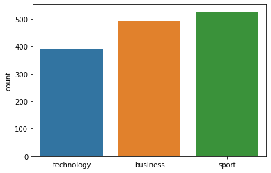

```python
# # ปริ้นจำนวนข้อมูล target เพื่อดูว่าข่าวส่วนใหญ่เป็นประเภทใด
import seaborn
ax = seaborn.countplot(x=dftarget)
```

## text processing ประกอบไปด้วยกระบวนการดังนี้

### 1. cleaning or Remove Noisy Data

> คือการลบข้อมูล text ที่ไม่เกี่ยวข้องในการนำมาสร้าง model คือเป็นคำที่ไม่ได้สื่อถึงการรายงานข่าว รวมถึงสัญลักษ์ต่างๆจากที่ดึงมา

### 2. การตัดคำ (Tokenize)

> เป็นหน่วยของคำที่เราเลือกมาจาก word อีกที หมายถึงหากมีค่าสัญลักษณ์แปลกๆเกิดขึ้นใน text การใช้ Tokenize จะช่วยเลือกคำที่ใช้ได้ออกมา

### 3. lemmatise

> คือการตัดคำต่างๆให้เหลือเฉพาะรากศัพท์ โดยเหตุผลที่ใช้ lemma เเทน stem เนื่องจากว่า lemma จะมีการตัดคำโดยอ้างอิงจาก dictionary จะทำให้ได้ผลลัพธ์ของคำที่สามารถเข้าใจได้ง่ายกว่า stem ที่เป็นการตัดคำเเบบหยาบๆ อีกทั้ง lemma จะช่วยประหยัดพื้นที่ในเรื่องของจำนวนคำที่มีความหมายซ้ำกันได้ด้วย

### 4. convert to lowercast

> แปลงเป็นตัวหนังสือพิมพ์เล็กทั้งหมด

### 5. remove stopword

> ดังนั้นเมื่อดูจากรายการคำที่พบบ่อยในเอกสารเเต่มักจะไม่ให้ประโยชน์ เราจึงจะทำการตัดคำ stop word ที่มีอยู่ในเอดสารเราออกด้วย

### 6. bag of word

> จะมีการนับจำนวนคำที่เกิดขึ้นในเเต่ละเอกสาร

### 7. TF-IDF Weighting ด้วยกับ CountVectorizer + TfidfTransformer = tfidfvectorizer

> หลังจากได้ค่าจำนวนคำจาก bag of word นำมาแปลงด้วย TfidfTransformer เพื่อได้ความถี่ของคำที่เกิดขึ้นจริงในเเต่ละเอกสาร ที่ใช้วิธีนี้เนื่องจากว่า การใช้ term weighting ในการให้ความถี่ของคำที่เกิดขึ้นจริงบนเอกสารทั้งหมด จะให้ประสิทธิภาพมากกว่าการนับจำนวนคำที่เกิดขึ้นในเเต่ละเอกสาร เพราะจะไม่เท่าเทียมในกรณีที่บางเอกสารยาว บางเอกสารสั้น ทำให้ประสิทธิภาพในการทำนายจะลดลงได้

### 8. ได้ document term Matrix ของ ข้อมูล content ทั้งหมด

### 1. cleaning or Remove Noisy Data

#### เมื่อผู้จัดทำได้สำรวจข้อมูลเเล้วพบว่า ในเนื้อหาข่าวจะมีคำที่ไม่เกี่ยวข้องด้วย เช่น \n , Return to article search results ที่จะมีเหมือนๆกันในทุกๆ document จึงจะทำการตัดคำเหล่านั้นออก เพื่อไม่ให้มีผลต่อผลลัพธ์ที่ได้ เเละยังเป็นการประหยัดพื้นที่เเละระยเวลาในการ tune ได้ด้วย

#### function สำหรับทำความสะอาดข้อมูล

```python
# text clening (ลบคำที่ไม่เกี่ยวข้องออก)
def clean_text(raw_document):

    # ลบคำที่ไม่เกี่ยวข้องออก
    for i in raw_document:
        raw_document = raw_document.strip("Return to article search results\n") #ลบคำนี้ออก เนื่องจากไม่มีผลต่อการนำไป
        raw_document = raw_document.replace("Comments are closed for this article.",'') #ลบคำนี้ออก เนื่องจากไม่มีผลต่อการนำไป

        return raw_document
```

#### จัดเก็บข้อมูลทั้งหมดเข้า list

```python
raw_documents = [] # ตั้งตัวแปรเพื่อเก็บข้อมูลหลังจาก clean เเล้ว
for i in raw_document: # วนลูปเอกสารข่าวทั้งหมดที่นำเข้ามา
    new = clean_text(i) # clean ในเเต่ละเอกสาร
    raw_documents.append(new) # เมื่อ clean เสร็จ ให้ append เข้า list raw_documents
print(raw_documents[:2]) # เเสดงผลตัวอย่าง
```

```
['The sporting industry has come a long way since the ‘60s. It has carved out for itself a niche with its roots so deep that I cannot fathom the sports industry showing any sign of decline any time soon - or later.  The reason can be found in this seemingly subtle difference - other industries have …
```

- โดยปกติเราสามารถนำข้อมูล มาเข้าโมเดลได้เลย เเต่กับ text มันยากสำหรับคอมพิวเตอร์ในการ train จึงต้องมีกระบวนการในการแปลง text ให้อยู่ในรูปแบบ matrix term (ตัวเลข) เพื่อใช้ในการ train model ได้ โดยจะทำผ่านกระบวนการดังนี้

### 2. Tokenize and 3. lemmatize function นี้จะเป็นการเลือกคำจาก word (ตัดคำออก)เเละยังไว้ซึ่งความหมายของคำเเต่ละคำด้วย

```python
# define the function
def lemma_tokenizer(text): # เป็น function เพื่อไว้ตัดคำ stop word รวมถึง ใช้รากคำในรูปแแบบ lemma

    from sklearn.feature_extraction.text import CountVectorizer
    standard_tokenizer = CountVectorizer().build_tokenizer() # สร้าง token เพื่อเลือกคำมาจาก word ทั้งหมด ดังนั้น token != word

    tokens = standard_tokenizer(text) # ตัดคำ รายการคำทั้งหมด

    lemmatizer = nltk.stem.WordNetLemmatizer() # ใช้ WordNetLemmatizer เพื่อลดรูปข้อความให้อยู่ในรูปเเบบ normal form of word
    lemma_tokens = [] #ตั้ง list เพื่อจัดเก็บคำที่ลดรูปแล้ว
    for token in tokens: # วนลูปเพื่อเลือกคำที่ผ่านการ token เเล้ว
        lemma_tokens.append( lemmatizer.lemmatize(token)) # แปลงคำใน tokens ด้วยรายการคำศัพท์ใน Dictionary ให้อยู่ในรูปฟอร์มพื้นฐาน
    return lemma_tokens
```

### 4.lowercase 5. remove stop word 6. bag of word

> กระบวนการนี้จะมีการกำหนด min df เเละ max df ของเอกสารทั้งหมดด้วย ผลลัพธ์หลังจาก run กระบวนการนี้คือ เราจะได้ จำนวนคำที่เกิดขึ้นในเเต่ละเอกสารโดยผ่านการเลือกคำที่เป็นไปตามเงื่อนไขที่ตั้งไว้เเล้ว เช่น min_df stop word

```python
# ใช้ CountVectorizer เพื่อแปลงจาก ข้อความ lemma_tokens ให้เป็นตัวเลขในรูปแบบ matrix โดยการนับคำที่เกิดขึ้นในเอกสาร
import nltk
nltk.download('wordnet')
from sklearn.feature_extraction.text import CountVectorizer
'''เรียกใช้ fn lemma_tokenizer ที่มีการจัดคำไว้ ตั้ง stop_word ที่เป็นภาษาอังกฤษเพื่อลบคำที่ไม่สื่อความหมายออกจากเอกสาร เช่นคำเชื่อม
เเละกำหนด mindf เเละ maxdf ด้วย หากมีคำที่ปรากฏบนเอกสาร < 20 เอกสาร หรือ > 700 เอกสารจะ ignore ทันที เพราะตัวเลข 700 ถือเป็นครึ่งหนึ่ง
ของจำนวนเอกสารทั้งหมด เเละ class ของข้อมูลชุดนี้มีจำนวน 3 class ผู้จัดทำเลยคิดว่าหากมี > ครึ่งหนึ่งของเอกสารอาจเป็นคำที่ฟุ่มเฟือย เเละไม่ได้บอกคุณลักษระเฉพาะ
ของเเต่ละเอกสารได้ เนื่องจากต้องการเปลียนค่าเป็นตัวพิมพ์เล็กด้วย จึงไม่ได้ใส่ lowercase เพราะ default จะกำหนดให้ return ตัวพิมพ์เล็ก'''
vectorizer = CountVectorizer(tokenizer=lemma_tokenizer, stop_words="english", min_df = 20, max_df=700)
Feature = vectorizer.fit_transform(raw_documents) # นำ ข่าวทั้งหมดให้เป็นไปตามเงื่อนไขที่ตั้งไว้ จะ return เป็นค่า bag of word ออกมา
print(Feature.todense()) # เรียกดู matix ความถี่ของคำ
print(Feature.shape)  #จะได้จำนวนข่าว = 1408 ข่าว , จำนวนคำที่ไม่ซ้ำกันทั้งหมดในข่าว = 2087
# print(X_train.todense())
```

```
[[ 0  0  0 ...  0  0  0]
 [ 2  2  0 ...  0  0  0]
 [ 1  1  0 ...  0  0  0]
 ...
 [ 1  0  0 ...  0 15  0]
 [ 0  0  0 ...  0  6  0]
 [ 0  0  0 ...  0  0  0]]
(1408, 2087)
```

#### ทดลองเรียกดูข้อมูลว่าเป็นตัวพิมพ์เล็กไหม

```python
terms = vectorizer.get_feature_names() # คำทั้งหมดที่ปรากฏ
print(terms[201:221]) # เลือกบางคำ
```

```
['associated', 'association', 'athens', 'athlete', 'athletics', 'atmosphere', 'attack', 'attacking', 'attempt', 'attention', 'auction', 'audience', 'audio', 'august', 'australia', 'australian', 'authority', 'auto', 'automatically', 'autumn']
```

#### หลังจากที่เราสร้างคลังคำศัพท์ เเละนับจำนวนคที่ปรากฎขึ้น (Bag-of-Word ด้วย CountVectorizer) CountVectorizer จะ return จำนวนของคำในเเต่ละเอกสารออกมา

> เเต่หากใช้เพียง CountVectorizer ความถี่ของคำจะมีปัญหาในกรณีที่เอกสารมีความยาวไม่เท่ากัน เเล้วดันเกิดคำนั้นซ้ำๆ จะส่งผลให้เกิดปัญหาในเรื่องของน้ำหนักความถี่ที่ได้จะไม่เท่ากัน ดังนั้นเราจึงนำ TF-IDF มาจัดการกับปัญหานี้ เพื่อลดน้ำหนักคำปกติทั่วๆไป เเละเพิ่มความถูกต้องในการนับคำ โดยจะทำต่อจาก CountVectorizer เพื่อเป็นการทำงานของ term Weighting

### 7. TF-IDF Weighting เพื่อได้ความถี่ของคำจากเอกสารทั้งหมด

> จากผลลัพธ์นี้เราจะได้ Document term matrix เพื่อสามารถเข้าสู่กระบวนการปกติในการ train model ได้

```python
# ใช้เพื่อเป็น tf-idf ในการคำนวนค่าความถี จาก Document ทั้งหมด
from sklearn.feature_extraction.text import TfidfTransformer
tfidf_transformer = TfidfTransformer()

# ใช้ ความถี่จาก bag of word เพื่อนับคำที่เกิดขึ้นโดยจะเป็นความถี่ที่เกิดขึ้นจากการนับคำเเล้วหารด้วยคำทั้งหมดในเอกสาร
X_Tfidf = tfidf_transformer.fit_transform(Feature)
# Y_Tfidf = tfidf_transformer.fit_transform(target)

print('X size  :',X_Tfidf.shape) # return จำนวน row column
print(X_Tfidf.todense()) # เเสดงตัวเลขความถี่ในรูปแบบ matrix
```

```
X size  : (1408, 2087)
[[0.         0.         0.         ... 0.         0.         0.        ]
 [0.06095425 0.06046855 0.         ... 0.         0.         0.        ]
 [0.02854119 0.02831376 0.         ... 0.         0.         0.        ]
 ...
 [0.02426885 0.         0.         ... 0.         0.69192239 0.        ]
 [0.         0.         0.         ... 0.         0.54849747 0.        ]
 [0.         0.         0.         ... 0.         0.         0.        ]]
```

ตอนนี้ผลลัพ์ที่ได้คือ term matrix ของข้อมูลเนื้อหาข่าวทั้งหมด ต่อไปจะทำการแปลง target จาก string ให้อยู่ในรูปเเบบตัวเลข ดังนี้

```python
# เรียกดูข้อมูล target
target[:5]
```

```
['technology', 'business', 'technology', 'business', 'sport']
```

#### แปลง target เป็น ตัวเลข

```python
from sklearn.preprocessing import LabelEncoder
labelEncoder = LabelEncoder() # เปลี่ยน target ให้เป็น 0, 1 ,2
labelEncoder.fit(target) # fit กับข้อมูล target ทั้งหมด
target = labelEncoder.transform(target) # แปลงจาก ตัวหนังสือ เป็น ตัวเลข
target[:5]
```

```
array([2, 0, 2, 0, 1], dtype=int64)
```

#### ดังนั้นจะได้ว่า

```
0 = business <br>
1 = sport <br>
2 = technology
```

```python
len(target) # จำนวนข้อมูล target
```

```
1408
```

```python
X_Tfidf.shape # เรียกดูจำนวนข้อมูล มีทั้งหมด 1408 เเถว (จำนวนข่าวทั้งหมด) มี 2087 feature : X_Tfidf = ตัวแปล X ในรูปแบบ term matrix
```

```
(1408, 2087)
```

```python
# เพื่อความเข้าใจขอเเทนตัวแปร X เเละ Y สำหรับใช้ เป็น ข้อมูล feature เเละ target ตามลำดับ
X = X_Tfidf
Y = target
```

### กระบวนการคร่าวๆ หลังจากนี้คือ

```
        1. ได้ document term matrix จากขั้นตอน text processing
        2. เเบ่ง test train
        3. นำ test train มาสร้าง Model จาก classifier ประเภทต่างๆ พร้อม tune parameter
        4. ได้ค่าความถูกต้อง ของเเต่ละโมเดล (โดยวิธีในการประเมินประสิทธิภาพของโมเดลเรานั้นจะพิจารณาค่า accuracy ของ model เเละ f1-score)
             - เหตุผลที่เลือกค่า f1-score เพราะเป็นค่าที่บ่งบอกถึง recall เเละ precision เลยเลือกที่จะพิจารณาเพื่อทราบค่าคร่าวๆของทั้ง 2 ได้
        5. เลือกใช้ model ที่ดีที่สุด
        6. ทดลองนำข้อมูลใหม่เข้ามา เพื่อดูว่า model สามารถทำนายถูกต้องหรือไม่
```

## 2. เเบ่ง test train ด้วย วิธี hold-out sampling

> เเบ่งเป็น 2 รูปแบบคือ
> - train 80 test 20
> - train 70 test 30

```python
# เเบ่ง test train 80:20
from sklearn.model_selection import train_test_split # '''เนื่องจากข้อมูลไม่ได้มีเยอะมาก จึงทดลองใช้ 80 20'''
X_train2 , X_test2 , y_train2 , y_test2 = train_test_split(X, Y, test_size=0.2,
                                                       random_state=42) # คือสุ่มทีละ 42 ตัว ใช้ค่านี้เนื่องจากเป็นค่าที่นิยมเเละใช้กันมากที่สุด
```

```python
# เเบ่ง test train 70:30
from sklearn.model_selection import train_test_split
X_train3 , X_test3 , y_train3 , y_test3 = train_test_split(X, Y, test_size=0.3,
                                                       random_state=42)
```

```python
print('X_train80 = ' , X_train2.shape ,' ||', 'X_train70 = ' , X_train3.shape)
print('y_train80 = ' , y_train2.shape,' || ', 'y_train70 = ' , y_train3.shape)
print('X_test20 = ' , X_test2.shape,' || ', 'X_test30 = ' , X_test3.shape)
print('y_test20 = ' , y_test2.shape ,' || ', 'y_test30 = ' , y_test3.shape)
```

```
X_train80 =  (1126, 2087)  || X_train70 =  (985, 2087)
y_train80 =  (1126,)  ||  y_train70 =  (985,)
X_test20 =  (282, 2087)  ||  X_test30 =  (423, 2087)
y_test20 =  (282,)  ||  y_test30 =  (423,)
```

## 3. เริ่มสร้าง model

> โดยเลือกใช้ classifier ประเภทต่างๆ เเละปรับ parameter เพื่อได้ Best parameter ในเเต่ละ model ดังนี้  
> K-NN  
> XGboost  
> Logistic Regression  
> Neural network  
> ensemble

## KNeighborsClassifier

> เนื่องจาก Knn เป็นหนึ่งในประเภท supervise learning ดังนั้นด้วยกับหลักการที่ว่ามันจะหาเพื่อนบ้านที่ใกล้ที่สุด เเละเลือกคำตอบจากผลลัพธ์ที่ได้มากที่สุด ดังนั้น ด้วยสมมติฐานของผู้เขียน การที่มันทำนายจากความคล้ายคลึงของคลาสต่างๆ จะช่วยให้เมื่อมันเจอข้อมูลใหม่ๆ จะสามารถคำนวณหาระยะห่างของตัวเลขข้อมูลได้ เเละติดสินใจได้ค่าที่ถูกต้องในคลาสต่างๆได้ เเต่เมื่อลองทดสอบดูเเล้วพบว่า ค่าความถูกต้องอาจจะยังไม่มาก ซึ่งอาจมาจากจำนวน attribute ของข้อมูลที่ใช้ train มีจำนวนมากๆ เเล้วส่งผลต่อ model

```python
from sklearn.model_selection import GridSearchCV
knn = KNeighborsClassifier() # กำหนด classifier
parameters = {
    'n_neighbors' : list(np.arange(3,60,2)),  # กำหนดจำนวนเพื่อนบ้านที่ใกล้ที่สุดตั้งเเต่ 3 - 60 จำนวน เพื่อ return ค่าที่เหมาะสมที่สุดสำหรับโมเดล
    'weights' : ['uniform', 'distance'], # รูปแบบการคำนวณค่า weight
    'metric' : ['euclidean', 'manhattan'] # เพื่อดูว่าต้องใช้การคำนวนระยะทางเเบบใดเพื่อได้ model ที่มีประสิทธิภาพมากที่สุด
}
'''จากรายการ parameters ที่ผู้จัดทำต้องการทราบคือ จำนวนเพื่อนบ้านที่ดีที่สุด
weight ที่มีผลต่อการคำนวณน้ำหนักในเเต่ละจุดข้อมูล เพื่อลดปัญหาการนำข้อมูลเข้าผิดกลุ่ม
เนื่องจากบางกรณี หากเราไม่มีการคำนวณค่าน้ำหนักของข้อมูลอื่นๆ การกำหนดเพียงค่า k อย่างเดียวอาจทำให้้ได้ผลของการเเบ่งกลุ่มที่ผิดพลาดได้'''

folds = 5 # กำหนด k-fold = 5 ซึ่งเป็นค่าที่นิยมใช้กันมากที่สุด

'''ช้คำสั่ง StratifiedKFold ซึ่งเอาไว้ใช้เมื่อต้องการแบ่งกลุ่มให้สัดส่วนคำตอบเท่าเดิมตอนทำ crossvalidation ในช่วงที่มีการนำข้อมูลมาเป็นทั้ง train เเละ test
ต้องการให้เลขสุ่มเรียงด้วยคีย์เวิร์ด shuffle=True เพื่อกันการนำเอาข้อมูลเเต่ละ fold ที่ซ้ำกัน'''
skf = StratifiedKFold(n_splits=folds, shuffle = True, random_state = 42)

knn_best = GridSearchCV(knn, parameters, cv=skf) # หา parameter ด้วย gridsearch
Knn2 = knn_best.fit(X_train2,y_train2)  # train ด้วยข้อมูล 80:20 , 70:30
knn3 = knn_best.fit(X_train3,y_train3)

print("Best param for test 20")
print(Knn2.best_params_ ) # จะได้ค่า n ที่ดีที่สุดสำหรับข้อมูลเเต่ละชุด

print("Best param for test 30")
print(knn3.best_params_)
```

```
Best param for test 20
{'metric': 'euclidean', 'n_neighbors': 45, 'weights': 'uniform'}
Best param for test 30
{'metric': 'euclidean', 'n_neighbors': 45, 'weights': 'uniform'}
```

กำหนดตัวแปลเพื่อเก็บค่า best parameter ไว้

```python
bestparamKNN = Knn2.best_params_ #  parameter ที่ได้เหมือนกะนจึงเก็บไว้ในตัวแปลเดียว
```

### สร้าง model ด้วย parameter ที่ดีที่สุด

### ใช้ข้อมูล test = 20 เเละ train = 80

```python
# ใช้ค่า parameter ที่ดีที่สุด
# knn = KNeighborsClassifier(bestparam20)
knn.set_params(**bestparamKNN) # เพื่อเรียกใช้เซตพารามีเตอร์ที่ดีที่สุดไว้ในตัวแปร
knn.fit(X_train2, y_train2) #  train
y_pred2 = knn.predict(X_test2) # ทำนายข้อมูลด้วย X_test
accuracyknn2 = accuracy_score(y_test2, y_pred2) # คำนวนค่า accuracy ของ model นี้
print("KNeighborsClassifier accuracy of test set = 0.2 is  : {:.2f}%". format(accuracyknn2*100))
```

```
KNeighborsClassifier accuracy of test set = 0.2 is  : 96.10%
```

#### f1_score value for train 80 test 20

```python
from sklearn.metrics import f1_score
f1_score = f1_score(y_test2, y_pred2,average='macro') # ใช้ค่าของข้อมูล test 20
print("f1_score for XGB test set = 0.2 is  : {:.2f}%". format(f1_score*100))
```

```
f1_score for XGB test set = 0.2 is  : 96.10%
```

### ใช้ข้อมูล test = 30 เเละ train = 70

> รูปแบบ code เหมือนกันกับ train test ด้านบน เพียงเเต่ต่างกันที่จำนวนข้อมูลเท่านั้น จึงขอไม่เขียนอธิบาย code เพิ่มเติมในส่วนของ train 70 test 30ในเเต่ละ model

```python
# ใช้ค่า parameter ที่ดีที่สุด
knn.set_params(**bestparamKNN)
knn.fit(X_train3, y_train3)
y_pred3 = knn.predict(X_test3)
accuracyknn3 = accuracy_score(y_test3, y_pred3)
print("KNeighborsClassifier accuracy of test set = 0.3 is  : {:.2f}%". format(accuracyknn3*100))
```

```
KNeighborsClassifier accuracy of test set = 0.3 is  : 95.51%
```

#### f1_score value for train 70 test 30

```python
from sklearn.metrics import f1_score
f1_score = f1_score(y_test3, y_pred3,average='macro') # ใช้ค่าของข้อมูล test 30
print("f1_score for XGB test set = 0.2 is  : {:.2f}%". format(f1_score*100))
```

```
f1_score for XGB test set = 0.2 is  : 95.47%
```

## XGboost

> XGboost เป็น model ที่มีการเรียนรู้ได้อย่างมีประสิทธิภาพ กล่าวคือ การเรียนเเล้วนำเอาข้อผิดพลาดกลับมาเรียนซ้ำๆ เพื่อสามารถลด error จากการเรียนรู้ก่อนๆ ได้ ทำให้ model ที่ใช้ XGboost จะช่วยลด bias รวมถึง overfit ได้ด้วย จึงคิดว่า model นี้จะทำให้การทำนายออกมาเเม่นยำ เเละมีประสิทธิภาพมากขึ้น

### กำหนด parameter เพื่อหา best params ด้วย RandomizedSearchCV

```python
'''กำหนด parameter คือ max depth เเละ n_estimators คือความลึกของ tree เเละจำนวน tree เพราะหากไม่มีการ กำหนดค่าพวกนี้ หรือใช้ค่าเหล่านี้
โดยไม่คำนึงถึงข้อมูลเรา อาจทำให้โมเดลที่ได้เกิด overfit ได้'''
parameters = {
    'max_depth': range (2, 10, 2),
    'n_estimators': range(60, 220, 40), # จำนวน tree ที่จะได้ค่า acc มากที่สุด
}


xgb = XGBClassifier(learning_rate=0.02, objective='multi:softmax') # กำหนด objective เพราะเป็น multiclass
# cross validation
folds = 5
skf = StratifiedKFold(n_splits=folds, shuffle = True)

# เพื่อได้ parameter ที่ได้ จึงกำหนดค่า n_iter ให้มันเทนรเป็นจำนวน 5ครั้ง  n_jobs ให้มัน train พร้อมๆกัน , เเละ verbose = ความละเอียดในการ train model
randomxgb = RandomizedSearchCV(xgb, param_distributions=parameters, n_iter=5, n_jobs=2, cv=skf, verbose=3, random_state=42)
xgb2 = randomxgb.fit(X_train2,y_train2) # train ด้วย ข้อมูล 80 20
xgb3 = randomxgb.fit(X_train3,y_train3) # train ด้วย ข้อมูล 70 30
print(xgb2.best_params_)
print(xgb3.best_params_)
```

```
Fitting 5 folds for each of 5 candidates, totalling 25 fits
```

```
[Parallel(n_jobs=2)]: Using backend LokyBackend with 2 concurrent workers.
[Parallel(n_jobs=2)]: Done  25 out of  25 | elapsed:  1.3min finished
```

```
Fitting 5 folds for each of 5 candidates, totalling 25 fits
```

```
[Parallel(n_jobs=2)]: Using backend LokyBackend with 2 concurrent workers.
[Parallel(n_jobs=2)]: Done  25 out of  25 | elapsed:  1.2min finished
```

```
{'n_estimators': 140, 'max_depth': 8}
{'n_estimators': 140, 'max_depth': 8}
```

#### กำหนดตัวแปรเพื่อเก็บค่า bestparams ของเเต่ละโมเดล

```python
xgb_bestparams = xgb2.best_params_
```

### ทดลองสร้าง model ด้วย best parameter

### ใช้ข้อมูล train 80 test 20

```python
xgb.set_params(**xgb_bestparams) # นำค่า best params มา ใช้
xgb.fit(X_train2,y_train2) # เเละใช้ train model
y_pred2 = xgb.predict(X_test2) # ทำนายค่า X test
# evaluate predictions
accuracy = accuracy_score(y_test2,y_pred2) # คำนวน acc ของการทำนาย
print("XGB accuracy of test set = 0.2 is  : {:.2f}%". format(accuracy*100))
```

```
XGB accuracy of test set = 0.2 is  : 91.84%
```

#### f1_score value for train 80 test 20

```python
from sklearn.metrics import f1_score
f1_score = f1_score(y_test2, y_pred2,average='macro') # ใช้ค่าของข้อมูล test 20
print("f1_score for XGB test set = 0.2 is  : {:.2f}%". format(f1_score*100))
```

```
f1_score for XGB test set = 0.2 is  : 91.70%
```

### ใช้ข้อมูล train 70 test 30

```python
# train 70 test 30
xgb.set_params(**xgb_bestparams)
# xgb = XGBClassifier(n_estimators= 140, max_dept= 8,learning_rate=0.05, objective='multi:softmax')
xgb.fit(X_train3,y_train3)
y_pred3 = xgb.predict(X_test3)
# evaluate predictions
accuracy = accuracy_score(y_test3,y_pred3)
print("XGB accuracy of test set = 0.3 is  : {:.2f}%". format(accuracy*100))
```

```
XGB accuracy of test set = 0.3 is  : 92.43%
```

#### f1_score value for train 70 test 30

```python
from sklearn.metrics import f1_score
f1_score = f1_score(y_test3, y_pred3,average='macro') # ใช้ค่าของข้อมูล test 30
print("f1_score for XGB test set = 0.3 is  : {:.2f}%". format(f1_score*100))
```

```
f1_score for XGB test set = 0.3 is  : 92.34%
```

## Logistic Regression

> โดยปกติ จะใช้กับ binary classification เพื่อใช้ทำนายความน่าจะเป็นว่าข้อมูลจะอยู่ class ใด เเต่ก็สามารถประยุกต์ใช้กับ multiclass-classification ได้เช่นกัน เพื่อทำนายโอกาสที่จะเป็น class ไหนได้จาก class ที่มี % มากที่สุด ผู้จัดทำจึงเห็นว่าเมื่อเราลองเทรนเเล้ว จะใช้การคำนวนค่าความน่าจะเป็นว่ารูปแบบข้อมูลเเบบนี้จะอยู่ class ใดนั้นน่าจะให้ผลลัพธ์ที่ดีด้วย

```python
# Grid search and cross validation
from sklearn.model_selection import GridSearchCV
from sklearn.linear_model import LogisticRegression
params={"penalty":["l1","l2"], # l1 l2 เพื่อกำหนดการคำนวนระยะทางเเบบ euclidean or manhattan l1-norm or l2-norm
       'C': [0.001, 0.01, 0.1, 1, 10]}   # ค่า c เพื่อได้ ค่า c ที่เหมาะสมในการ fit model ที่ลด overfitting ได้
LR=LogisticRegression() # ประกาศ model
folds = 5
skf = StratifiedKFold(n_splits=folds, shuffle = True, random_state = 1001) # กำหนดรูปแบบการทำ cross val
LR_cv=GridSearchCV(LR,params,cv=skf) # หา best params ด้วย gridsearch
LR_cv2 = LR_cv.fit(X_train2,y_train2) # train model 80 | 20
LR_cv3 = LR_cv.fit(X_train3,y_train3) #train model 70|30
print("tuned hpyerparameters :(best parameters) ",LR_cv2.best_params_)
print("tuned hpyerparameters :(best parameters) ",LR_cv3.best_params_)
```

```
tuned hpyerparameters :(best parameters)  {'C': 10, 'penalty': 'l2'}
tuned hpyerparameters :(best parameters)  {'C': 10, 'penalty': 'l2'}
```

```python
LR_bestparam = LR_cv2.best_params_
```

### ใช้ข้อมูล test = 20 เเละ train = 80

```python
# LR=LogisticRegression(C=10,penalty="l2")
LR.set_params(**LR_bestparam) # เรียกใช้ best params
LR2 = LR.fit(X_train2,y_train2) # train with test 20
pred=LR2.predict(X_test2)
accuracylr2 = accuracy_score(y_test2, pred) # ค่า accuracy
print("Accuracy for LogisticRegression of test set = 0.2 is  : {:.2f}%". format(accuracylr2*100))
```

```
Accuracy for LogisticRegression of test set = 0.2 is  : 98.58%
```

#### f1_score value for train 80 test 20

```python
from sklearn.metrics import f1_score
f1_score = f1_score(y_test2, pred,average='macro') # ใช้ค่าของข้อมูล test 20
print("f1_score for LogisticRegression test set = 0.2 is  : {:.2f}%". format(f1_score*100))
```

```
f1_score for LogisticRegression test set = 0.2 is  : 98.61%
```

### ใช้ข้อมูล test = 30 เเละ train = 70

```python
LR.set_params(**LR_bestparam)
LR3 = LR.fit(X_train3,y_train3)
pred=LR3.predict(X_test3)
accuracylr3 = accuracy_score(y_test3, pred)
print("Accuracy for LogisticRegression of test set = 0.3 is  : {:.2f}%". format(accuracylr3*100))
```

```
Accuracy for LogisticRegression of test set = 0.3 is  : 97.87%
```

#### f1_score value for train 70 test 30

```python
from sklearn.metrics import f1_score
f1_score = f1_score(y_test3, pred,average='macro') # ใช้ค่าของข้อมูล test 30
print("f1_score for LogisticRegression  test set = 0.3 is  : {:.2f}%". format(f1_score*100))
```

```
f1_score for LogisticRegression  test set = 0.3 is  : 97.86%
```

## Neural Network

> เนื่องจาก Neural network ใช้เวลาสอนหรือเรียนรู้นาน จึงคิดว่ายิ่งเรียนรู้ได้ลึกซึ้งเพียงใดความถุกต้องจึงมีค่ามากขึ้นด้วย เเละยังช่วยจัดการข้อมูล train ที่มีค่า error ให้ลดลงได้ เเละที่สำคัญคือ Neural Network จะมีการทำ Optimization Algorithms ที่จะช่วยให้ปรับปรุงค่าต่างๆ ใน ซึ่งหน้าที่ของมันคือปรับปรุงค่าต่างๆใน neural network ให้ผลลัพธ์ที่ได้ ใกล้เป้าหมายมากขึ้น จึงเลือกใช้ เพื่อหวังว่าโมเดลที่ได้จะมีประสิทธิภาพ

```python
from sklearn.neural_network import MLPClassifier
NN = MLPClassifier()
'''กำหนด parameter สำหรับ neural network ด้วยการกำหนด hidden layer ที่เหมาะสมเพื่อให้การ train มีประสิทธิภาพ'''
parameter = {
    'hidden_layer_sizes': [(50,50,50), (50,100,50), (100,)],
    'activation': ['relu','softmax'],
    'solver': ['sgd', 'adam'],
    'alpha': [0.0001, 0.05],
    'learning_rate': ['constant','adaptive'],
}
folds = 5
skf = StratifiedKFold(n_splits=folds, shuffle = True, random_state = 1001)
NNgrid = GridSearchCV(NN, parameter, n_jobs=-1, cv=skf) # Tune parameter
NN2 = NNgrid.fit(X_train2, y_train2) # train  80 20
NN3 = NNgrid.fit(X_train3, y_train3) # train  80 20
print(NN2.best_params_) #  return ค่า best params
print(NN3.best_params_)
```

```
{'activation': 'relu', 'alpha': 0.0001, 'hidden_layer_sizes': (50, 100, 50), 'learning_rate': 'constant', 'solver': 'adam'}
{'activation': 'relu', 'alpha': 0.0001, 'hidden_layer_sizes': (50, 100, 50), 'learning_rate': 'constant', 'solver': 'adam'}
```

```python
NNbestparam = NN2.best_params_ # เก็บ parameter ไว้ในตัวแปร NNbestparam
```

### ใช้ข้อมูล test = 20 เเละ train = 80

```python
NN.set_params(**NNbestparam) # เรียกใช้ best params
NN.fit(X_train2, y_train2) # train ข้อมูลด้วย best params
pred =NN.predict(X_test2) # ทำนายค่า X test
accuracynn = accuracy_score(y_test2, pred) # เทียบว่าตรงกับผลลัพธ์ไหม
print("Accuracy for neural_network of test set = 0.2 is  : {:.2f}%". format(accuracynn*100))
```

```
Accuracy for neural_network of test set = 0.2 is  : 98.94%
```

#### f1_score value for train 80 test 20

```python
from sklearn.metrics import f1_score
f1_score = f1_score(y_test2, pred,average='macro') # ใช้ค่าของข้อมูล test 20
print("f1_score for neural network test set = 0.2 is  : {:.2f}%". format(f1_score*100))
```

```
f1_score for neural network test set = 0.2 is  : 98.94%
```

### ใช้ข้อมูล test = 30 เเละ train = 70

```python
NN.set_params(**NNbestparam)
NN.fit(X_train3, y_train3)
pred =NN.predict(X_test3)
accuracynn3 = accuracy_score(y_test3, pred)
print("Accuracy for neural_network of test set = 0.3 is  : {:.2f}%". format(accuracynn3*100))
```

```
Accuracy for neural_network of test set = 0.3 is  : 98.35%
```

#### f1_score value for train 70 test 30

```python
from sklearn.metrics import f1_score
f1_score = f1_score(y_test3, pred,average='macro')
print("f1_score for neural network test set = 0.3 is  : {:.2f}%". format(f1_score*100))
```

```
f1_score for neural network test set = 0.3 is  : 98.33%
```

## ensembles with individual model ใช้ best parameter ของเเต่ละ classifier มาใช้ใน ensembles

```python
# ensemble with individual model  bestparamKNN ,xgb_bestparams , LR_bestparam, NNbestparam
from sklearn.ensemble import VotingClassifier
''' ขั้นตอนนี้จะเป็นการนำเอาค่า best parameter ของ ทั้ง 4 model ที่ทำไว้ได้แก่ [knn, xgboost, logistic regression เเละ neural network] มา train
ด้วย ensemble ดดยมีความคาดหวังว่าจะได้ ค่า accuracy ที่มากขึ้น '''
estimator = [('Knn',knn.set_params(**bestparamKNN) ),('xgb',xgb.set_params(**xgb_bestparams)),
             ('LR' ,LR.set_params(**LR_bestparam) ), ('NN' ,NN.set_params(**NNbestparam))] #
# ใช้ voting เเบบ soft เนื่องจาก เราใช้จำนวน 4 โมเดล จึงไม่เหมาะกับเเบบ hard ที่เป็นลักษณะ majority voting
ensemble = VotingClassifier(estimator,voting='soft')
ensemble.fit(X_train2,y_train2) # fit ข้อมูลที่ถูกเเบ่งด้วย 80 20 เท่านั้น เพราะเมื่อพิจารณาดูเเล้ว การเเบ่ง 80 20 นั้นได้ค่า accuracy มากกว่า
pred =ensemble.predict(X_test2) # ทำนายค่า X_test
accuracy = accuracy_score(y_test2, pred) # คำนวนค่าความถูกต้องของ model
print("Ensemble model perform = {:.2f}%". format(accuracy*100))
```

```
Ensemble model perform = 98.58%
```

## สรุป ค่า accuracy ของเเต่ละโมเดล ที่ได้จากการทดลอง

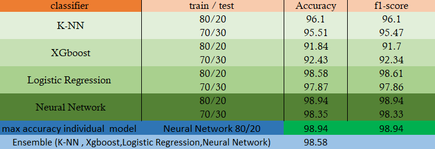

### test model neural network

```python
NeuralN_test = []
for i in range(20,35,1): # เลือกข้อมูลมาทำนายข่าวที่ 20-30
    predict_NN = NN.predict(X_Tfidf[i]) # ทำนายข้อมูลจาก document term matrix ที่ได้ กำหนดไว้ก่อนหน้า
    NeuralN_test.append('%.0f' % (predict_NN))

print('ผลลัพธ์ที่เป็นค่าจริงของข้อมูลที่นำมาทำนาย ข่าวที่ 20 - 30 :' , (target[20:35]))
print('---------------------------------------------------------------------------------------------------------')
print('Predicted Value of neural network :', (NeuralN_test))
```

```
ผลลัพธ์ที่เป็นค่าจริงของข้อมูลที่นำมาทำนาย ข่าวที่ 20 - 30 : [1 0 1 1 1 2 0 2 1 0 2 0 1 0 0]
---------------------------------------------------------------------------------------------------------
Predicted Value of neural network : ['1', '0', '1', '1', '1', '2', '0', '2', '1', '0', '2', '0', '1', '0', '0']
```

> เเต่ถ้าในกรณีที่ต้องการความเเม่นยำของ model อาจจะเลือก model 3 model ที่ให้ค่า accuracy มากที่สุด มาทดลองกับข้อมูลใหม่ๆ เเล้วใช้ majority voting ในการทำนายผลลัพธ์ที่ได้จากทั้ง 3 model ยกตัวอย่างเช่น neural network ทำนายได้ 0 , ensembles ทำนาย ได้ 1 , logistic regression ทำนายได้ 1 ก็จะเลือกผลลัพธ์สุดท้ายคือ 1 เป็นต้น

#### หมายเหตุ :

- หากผู้จัดทำ รายงานสิ่งใดผิดพลาดประการใดต้องขออภัยมา ณ ที่นี้ด้วยค่ะ